# Debugging a model: World Cup football

Author

Andrew Gelman and Aki Vehtari

Published

2021-01-12

Modified

2026-08-26

This notebook includes the code for the Bayesian Workflow book Chapter 23 *Debugging a model: World Cup football*.

# 1 World Cup 2014 team performance analysis

We use an item-response model such as described in the previous chapter to fit a model to estimate the abilities of the teams in the 2014 football World Cup. We use score differentials as data (ignoring the shoot-outs).

The forthcoming Bayesian workflow book has more information about the modeling task, but this version of the code was made available early, as it includes illustration of predictive performance comparison of continuous and discrete models.

Game scores could be modelled with a discrete bivariate Poisson model, and score differences with Poisson difference models (Karlis and Ntzoufras 2003), which are commonly used in analysis of sports data. But we’ll start with continuous models and discretized continuous models to illustrate how those can be compared, and eventually build also models using naturally discrete data models.

**Load packages**

````r
library(rprojroot)
root <- has_file(".Bayesian-Workflow-root")$make_fix_file()
library(cmdstanr)
# CmdStanR output directory makes Quarto cache to work
dir.create(root("world_cup", "stan_output"), showWarnings = FALSE)
options(cmdstanr_output_dir = root("world_cup", "stan_output"))
options(mc.cores = 4)
library(posterior)
options(
  tibble.print_max = 35,
  pillar.neg = FALSE,
  pillar.subtle = FALSE,
  pillar.sigfig = 2
)
library(bayesplot)
library(ggplot2)
theme_set(bayesplot::theme_default(base_family = "sans", base_size=14))
library(arm)
library(loo)
library(dplyr)
library(readr)

print_stan_code <- function(code) {
  if (isTRUE(getOption("knitr.in.progress")) &&
        identical(knitr::opts_current$get("results"), "asis")) {
    # In render: emit as-is so Pandoc/Quarto does syntax highlighting
    block <- paste0("```stan", "\n", paste(code, collapse = "\n"), "\n", "```")
    knitr::asis_output(block)
  } else {
    writeLines(code)
  }
}
````

# 2 Data

Data include 64 game results from World Cup 2014 and Soccer Power Index that was available on the internet a month before the tournament (Silver 2014). We took the rankings, with Brazil at the top (getting a score of 32) and Australia at the bottom (with a score of 1), and then for simplicity in interpretation of the parameters we rescaled these to have mean 0 and standard deviation 1/2, to get ``prior scores’’ that ranged from $-0.83$ to $+0.83$.

```r
powerindex <- read_csv(root("world_cup", "data","soccerpowerindex.csv")) |>
  mutate(prior_score = as.vector(scale(rev(index))/2))
teamnames <- powerindex$team
worldcup2014 <- read_csv(root("world_cup", "data", "worldcup2014.csv")) |>
  mutate(team_1 = match(team1, teamnames),
         team_2 = match(team2, teamnames))
N_games <- nrow(worldcup2014)
gamenames <- with(worldcup2014,
                  rev(paste(teamnames[team_1], "vs.", teamnames[team_2])))
```

## 2.1 Data for Stan

```r
stan_data <- with(
  worldcup2014,
  list(
    N_teams = nrow(powerindex),
    N_games = N_games,
    team_1 = team_1,
    score_1 = score1,
    team_2 = team_2,
    score_2 = score2,
    prior_score = powerindex$prior_score,
    df = 7
  )
)
```

# 3 First model

The first model uses Student’s $t$ for square root of score difference. It’s not particularly well justified model, but that is what Andrew first thought and it turned out to be useful for illustration.

The model structure is as follows: if game $i$ has teams $j_1$ and team $j_2$ playing, and they score $z_1$ and $z_2$ goals, respectively, then the data point for this game is $y_i = \mbox{sign}(z_1-z_2)*\sqrt{|z_1-z_2|}$, and the data model is: $y_i \sim \mbox{normal}(a_{j_1[i]}-a_{j_2[i]}, \sigma_y)$, where $a_{j_1}$ and $a_{j_2}$ are the ability parameters (to use psychometrics jargon) for the two teams and $\sigma_y$ is a scale parameter estimated from the data.

$$y_i \sim \mbox{t}_{\nu}(a_{j_1[i]}-a_{j_2[i]}, \sigma_y),$$
setting the degrees of freedom to $\nu=7$.

Stan model

```r
model_1 <- cmdstan_model(stan_file = root("world_cup", "worldcup_first_try.stan"))
```

```r
print_stan_code(model_1$code())
```

```stan
/* This program has a mistake in it, as will be explained later */

data {
  int N_teams;
  int N_games;
  vector[N_teams] prior_score;
  array[N_games] int team_1;
  array[N_games] int team_2;
  vector[N_games] score_1;
  vector[N_games] score_2;
  real df;
}
transformed data {
  vector[N_games] dif = score_1 - score_2;
  vector[N_games] sqrt_dif;
  for (i in 1:N_games) {
    sqrt_dif[i] = (step(dif[i]) - 0.5) * sqrt(abs(dif[i]));
  }
}
parameters {
  vector[N_teams] alpha;
  real b;
  real<lower=0> sigma_a;
  real<lower=0> sigma_y;
}
transformed parameters {
  vector[N_teams] a = b * prior_score + sigma_a * alpha;
}
model {
  alpha ~ normal(0, 1);
  b ~ normal(0, 1);
  sigma_a ~ normal(0, 1);
  sigma_y ~ normal(0, 1);
  sqrt_dif ~ student_t(df, a[team_1] - a[team_2], sigma_y);
}
```

Fit the model and show the results

```r
fit_1 <- model_1$sample(data = stan_data, refresh = 0)
```

```r
fit_1$summary(c("a", "b", "sigma_a", "sigma_y"))
```

```
# A tibble: 35 × 10
   variable    mean  median    sd   mad      q5    q95  rhat ess_bulk ess_tail
   <chr>      <dbl>   <dbl> <dbl> <dbl>   <dbl>  <dbl> <dbl>    <dbl>    <dbl>
 1 a[1]      0.28    0.29   0.14  0.14   0.043   0.49   1.0     3665.    3447.
 2 a[2]      0.37    0.36   0.12  0.12   0.17    0.58   1.00    5804.    3285.
 3 a[3]      0.49    0.47   0.16  0.16   0.25    0.77   1.0     1884.    3260.
 4 a[4]      0.17    0.19   0.18  0.17  -0.15    0.42   1.0     2394.    2851.
 5 a[5]      0.27    0.28   0.15  0.13   0.021   0.51   1.0     6204.    3089.
 6 a[6]      0.30    0.29   0.14  0.12   0.082   0.53   1.00    4106.    2736.
 7 a[7]      0.34    0.32   0.14  0.14   0.13    0.59   1.0     3690.    3404.
 8 a[8]      0.14    0.16   0.16  0.14  -0.14    0.38   1.0     5035.    2812.
 9 a[9]      0.036   0.059  0.17  0.17  -0.27    0.28   1.0     2491.    3070.
10 a[10]     0.20    0.19   0.13  0.12  -0.0040  0.43   1.0     4170.    2995.
11 a[11]     0.34    0.32   0.16  0.18   0.10    0.63   1.0     1539.    2902.
12 a[12]     0.045   0.060  0.15  0.13  -0.22    0.27   1.0     4380.    3058.
```

[output cut: 23 more lines]

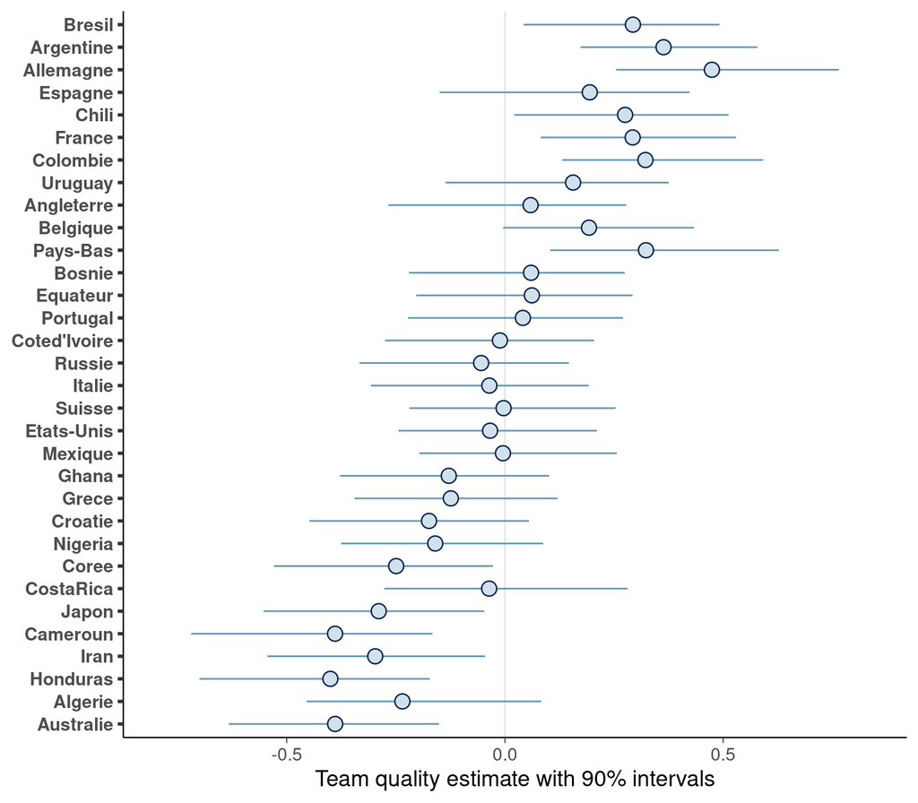

Figure 1

```r
fit_1$draws("a") |>
  mcmc_intervals(prob = 0) +
  scale_y_discrete(labels = rev(teamnames), limits = rev) +
  labs(x = "Team quality estimate with 90% intervals")
#if (savefigs) ggsave(root("world_cup/figs","worldcup_1.pdf", height=7, width=8))
```

## 3.1 Check fit of the first model

```r
model_1_rep <- cmdstan_model(stan_file = root("world_cup", "worldcup_with_replication.stan"))
```

```r
print_stan_code(model_1_rep$code())
```

```stan
/* This program has a mistake in it, as will be explained later */

data {
  int N_teams;
  int N_games;
  vector[N_teams] prior_score;
  array[N_games] int team_1;
  array[N_games] int team_2;
  vector[N_games] score_1;
  vector[N_games] score_2;
  real df;
}
transformed data {
  vector[N_games] dif = score_1 - score_2;
  vector[N_games] sqrt_dif;
  for (i in 1:N_games) {
    sqrt_dif[i] = (step(dif[i]) - 0.5)*sqrt(abs(dif[i]));
  }
}
parameters {
  vector[N_teams] alpha;
  real b;
  real<lower=0> sigma_a;
  real<lower=0> sigma_y;
}
transformed parameters {
  vector[N_teams] a = b * prior_score + sigma_a * alpha;
}
model {
  alpha ~ normal(0, 1);
  b ~ normal(0, 1);
  sigma_a ~ normal(0, 1);
  sigma_y ~ normal(0, 1);
  sqrt_dif ~ student_t(df, a[team_1] - a[team_2], sigma_y);
}
generated quantities {
  vector[N_games] y_rep;
  vector[N_games] y_rep_original_scale;
  for (n in 1:N_games) {
    y_rep[n] = student_t_rng(df, a[team_1[n]] - a[team_2[n]], sigma_y);
  }
  y_rep_original_scale = y_rep .* abs(y_rep);
}
```

```r
fit_1_rep <- model_1_rep$sample(data = stan_data, refresh = 0)
```

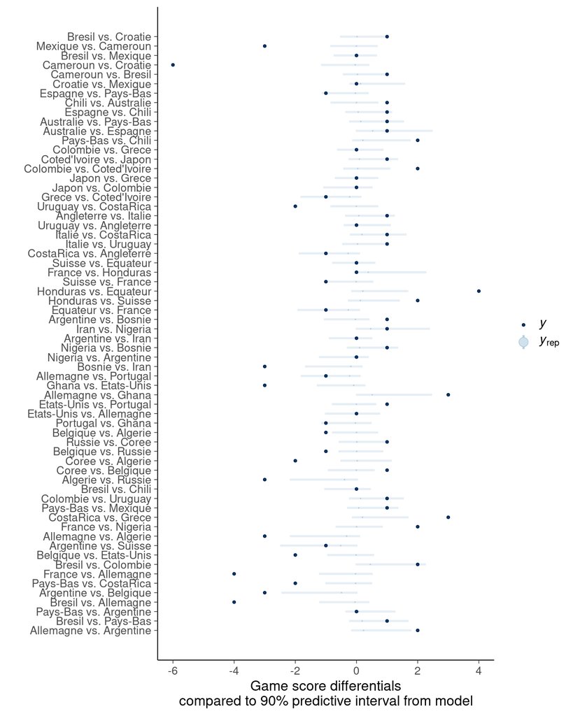

Figure 2

```r
ppc_intervals(
  y = stan_data$score_1 - stan_data$score_2,
  yrep = fit_1_rep$draws("y_rep_original_scale", format = "draws_matrix"),
  fatten = 0,
  prob = 1e-12
) +
  scale_x_continuous(labels = gamenames, breaks=1:64)+
  labs(y="Game score differentials\ncompared to 90% predictive interval from model",
       x="") +
  coord_flip()
#if (savefigs) ggsave(root("world_cup/figs","worldcup_3.pdf", height=10, width=8))
```

# 4 Second model without sqrt transformation

```r
model_2 <- cmdstan_model(stan_file = root("world_cup", "worldcup_no_sqrt.stan"))
```

```r
print_stan_code(model_2$code())
```

```stan
data {
  int N_teams;
  int N_games;
  vector[N_teams] prior_score;
  array[N_games] int team_1;
  array[N_games] int team_2;
  vector[N_games] score_1;
  vector[N_games] score_2;
  real df;
}
transformed data {
  vector[N_games] dif = score_1 - score_2;
}
parameters {
  vector[N_teams] alpha;
  real b;
  real<lower=0> sigma_a;
  real<lower=0> sigma_y;
}
transformed parameters {
  vector[N_teams] a = b * prior_score + sigma_a * alpha;
}
model {
  alpha ~ normal(0, 1);
  b ~ normal(0, 1);
  sigma_a ~ normal(0, 1);
  sigma_y ~ normal(0, 1);
  dif ~ student_t(df, a[team_1] - a[team_2], sigma_y);
}
generated quantities {
  vector[N_games] y_rep;
  for (n in 1:N_games) {
    y_rep[n] = student_t_rng(df, a[team_1[n]] - a[team_2[n]], sigma_y);
  }
}
```

```r
fit_2 <- model_2$sample(data = stan_data, refresh = 0)
```

```r
fit_2$summary(c("a", "b", "sigma_a", "sigma_y"))
```

```
# A tibble: 35 × 10
   variable    mean median    sd   mad     q5    q95  rhat ess_bulk ess_tail
   <chr>      <dbl>  <dbl> <dbl> <dbl>  <dbl>  <dbl> <dbl>    <dbl>    <dbl>
 1 a[1]      0.81    0.83   0.38  0.35  0.15   1.4     1.0    4568.    3260.
 2 a[2]      0.84    0.84   0.32  0.29  0.33   1.4     1.0    5728.    3274.
 3 a[3]      1.1     1.0    0.41  0.38  0.51   1.8     1.0    2867.    3068.
 4 a[4]      0.54    0.61   0.44  0.37 -0.29   1.1     1.0    2749.    3032.
 5 a[5]      0.71    0.71   0.36  0.31  0.13   1.3     1.0    4517.    2659.
 6 a[6]      0.81    0.78   0.36  0.31  0.29   1.4     1.0    3573.    2759.
 7 a[7]      0.84    0.78   0.38  0.34  0.31   1.5     1.0    2775.    3393.
 8 a[8]      0.35    0.40   0.38  0.32 -0.33   0.91    1.0    3479.    3055.
 9 a[9]      0.23    0.30   0.40  0.33 -0.53   0.77    1.0    2736.    2686.
10 a[10]     0.43    0.41   0.32  0.26 -0.086  0.97    1.0    4932.    3058.
11 a[11]     0.70    0.62   0.42  0.39  0.16   1.5     1.0    1880.    3177.
12 a[12]     0.20    0.23   0.37  0.27 -0.46   0.77    1.0    3842.    2449.
```

[output cut: 23 more lines]

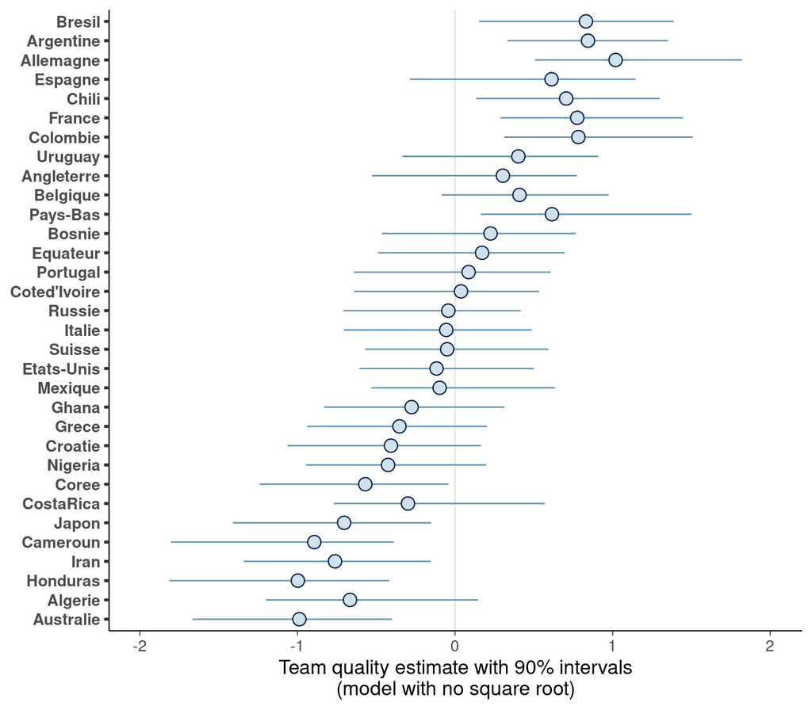

Figure 3

```r
fit_2$draws("a") |>
  mcmc_intervals(prob = 0) +
  scale_y_discrete(labels = rev(teamnames), limits = rev) +
  labs(x = "Team quality estimate with 90% intervals\n(model with no square root)")
#if (savefigs) ggsave(root("world_cup/figs","worldcup_4.pdf", height=7, width=8))
```

## 4.1 Check fit of the second model to data

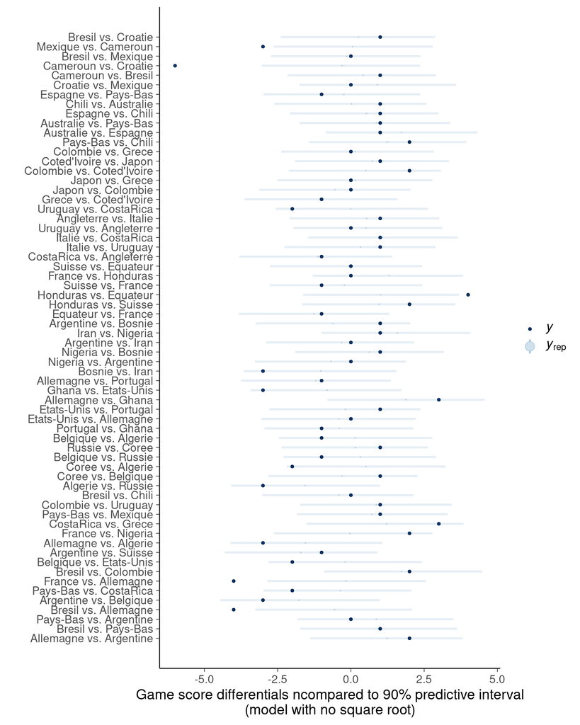

Figure 4

```r
ppc_intervals(
  y = stan_data$score_1 - stan_data$score_2,
  yrep = fit_2$draws("y_rep", format = "draws_matrix"),
  fatten = 0,
  prob = 1e-12
) +
  scale_x_continuous(labels = gamenames, breaks = 1:64)+
  labs(y = "Game score differentials ncompared to 90% predictive interval\n(model with no square root)", x = "") +
  coord_flip()
#if (savefigs) ggsave(root("world_cup/figs","worldcup_5.pdf", height=10, width=8))
```

# 5 Fix the first model

```r
model_3 <- cmdstan_model(stan_file = root("world_cup", "worldcup_fixed.stan"))
```

```r
print_stan_code(model_3$code())
```

```stan
/* The error in the transformed data block has been fixed */
data {
  int N_teams;
  int N_games;
  vector[N_teams] prior_score;
  array[N_games] int team_1;
  array[N_games] int team_2;
  vector[N_games] score_1;
  vector[N_games] score_2;
  real df;
}
transformed data {
  vector[N_games] dif = score_1 - score_2;
  vector[N_games] sqrt_dif;
  for (i in 1:N_games){
    sqrt_dif[i] = 2 * (step(dif[i]) - 0.5) * sqrt(abs(dif[i]));
  }
}
parameters {
  vector[N_teams] alpha;
  real b;
  real<lower=0> sigma_a;
  real<lower=0> sigma_y;
}
transformed parameters {
  vector[N_teams] a = b * prior_score + sigma_a * alpha;
}
model {
  alpha ~ normal(0, 1);
  b ~ normal(0, 1);
  sigma_a ~ normal(0, 1);
  sigma_y ~ normal(0, 1);
  sqrt_dif ~ student_t(df, a[team_1] - a[team_2], sigma_y);
}
generated quantities {
  vector[N_games] y_rep;
  vector[N_games] y_rep_original_scale;
  vector[N_games] log_lik;
  for (n in 1:N_games) {
    y_rep[n] = student_t_rng(df, a[team_1[n]] - a[team_2[n]], sigma_y);
  }
  y_rep_original_scale = y_rep .* abs(y_rep);
}
```

```r
fit_3 <- model_3$sample(data = stan_data, refresh = 0)
```

```r
fit_3$summary(c("a", "b", "sigma_a", "sigma_y"))
```

```
# A tibble: 35 × 10
   variable    mean median    sd   mad      q5    q95  rhat ess_bulk ess_tail
   <chr>      <dbl>  <dbl> <dbl> <dbl>   <dbl>  <dbl> <dbl>    <dbl>    <dbl>
 1 a[1]      0.57    0.59   0.28  0.27  0.093   1.0    1.0     3527.    3318.
 2 a[2]      0.73    0.72   0.25  0.23  0.33    1.2    1.0     4707.    3064.
 3 a[3]      0.96    0.94   0.32  0.32  0.49    1.5    1.0     1708.    2376.
 4 a[4]      0.33    0.37   0.37  0.34 -0.33    0.85   1.00    2209.    2609.
 5 a[5]      0.54    0.54   0.28  0.25  0.077   1.0    1.0     5735.    3142.
 6 a[6]      0.60    0.58   0.28  0.25  0.17    1.1    1.0     2669.    1642.
 7 a[7]      0.67    0.64   0.30  0.29  0.24    1.2    1.0     2802.    1998.
 8 a[8]      0.27    0.31   0.30  0.28 -0.25    0.74   1.0     3354.    3364.
 9 a[9]      0.059   0.11   0.34  0.33 -0.56    0.53   1.0     1958.    2966.
10 a[10]     0.40    0.38   0.26  0.24  0.0022  0.87   1.0     3857.    2249.
11 a[11]     0.66    0.64   0.32  0.35  0.21    1.2    1.0     1396.    2390.
12 a[12]     0.089   0.12   0.30  0.26 -0.45    0.54   1.00    3873.    3028.
```

[output cut: 23 more lines]

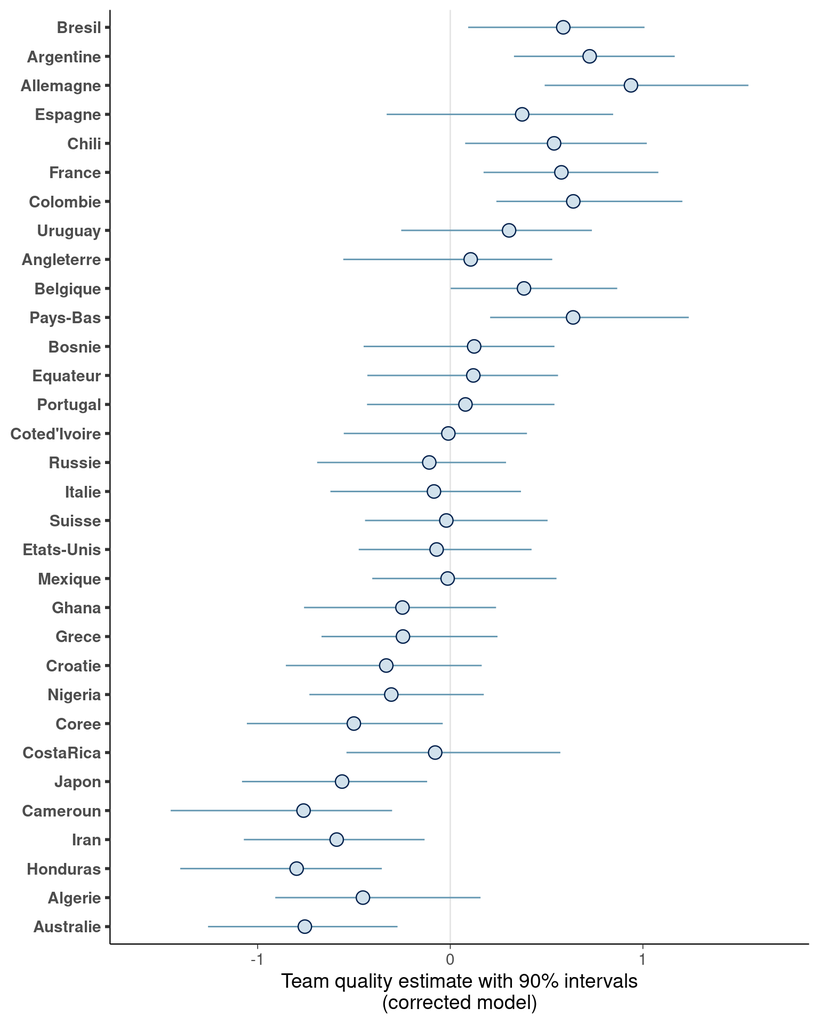

Figure 5

```r
fit_3$draws("a") |>
  mcmc_intervals(prob = 0) +
  scale_y_discrete(labels = rev(teamnames), limits = rev) +
  labs(x = "Team quality estimate with 90% intervals\n(corrected model)")
#if (savefigs) ggsave(root("world_cup/figs","worldcup_6.pdf", height=7, width=8))
```

## 5.1 Check the fit of the fixed first model

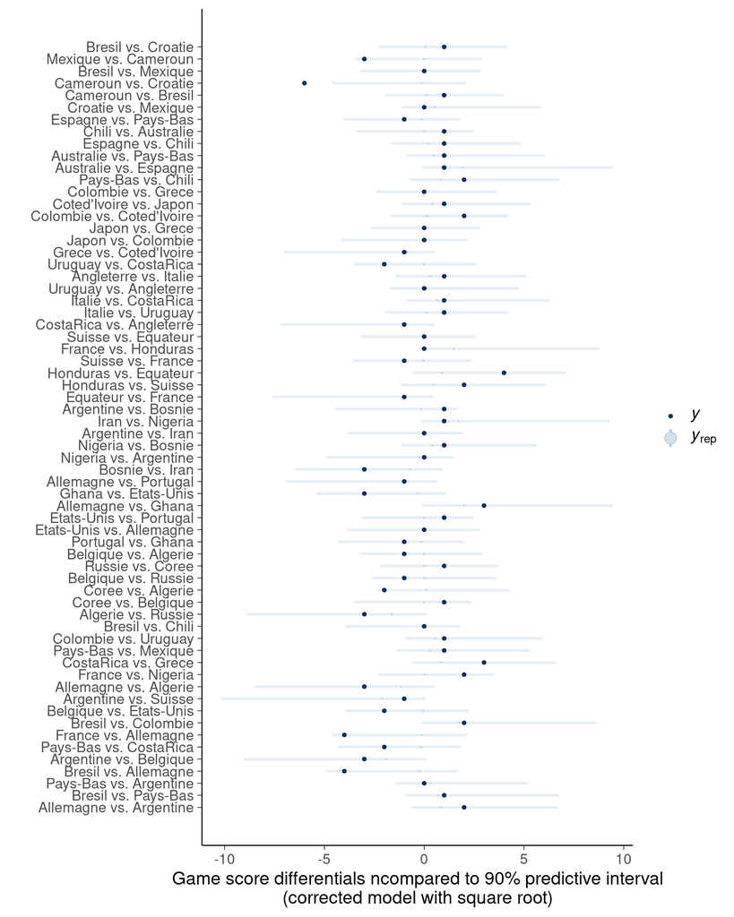

Figure 6

```r
ppc_intervals(
  y = stan_data$score_1 - stan_data$score_2,
  yrep = fit_3$draws("y_rep_original_scale", format = "draws_matrix"),
  fatten = 0,
  prob = 1e-12
) +
  scale_x_continuous(labels = gamenames, breaks = 1:64) +
  labs(y = "Game score differentials ncompared to 90% predictive interval\n(corrected model with square root)", x = "") +
  coord_flip()
#if (savefigs) ggsave(root("world_cup/figs","worldcup_7.pdf", height=10, width=8))
```

## 5.2 Fit the same model without the powerindex prior

set b=0 in the data

```r
model_3_no_prior <- cmdstan_model(stan_file = root("world_cup", "worldcup_no_prior.stan"))
```

```r
print_stan_code(model_3_no_prior$code())
```

```stan
data {
  int N_teams;
  int N_games;
  vector[N_teams] prior_score;
  array[N_games] int team_1;
  array[N_games] int team_2;
  vector[N_games] score_1;
  vector[N_games] score_2;
  real df;
  real b;  // To remove the prior score in the model, just set b=0 when running this program.
}
transformed data {
  vector[N_games] dif = score_1 - score_2;
  vector[N_games] sqrt_dif;
  for (i in 1:N_games){
    sqrt_dif[i] = 2 * (step(dif[i]) - 0.5) * sqrt(abs(dif[i]));
  }
}
parameters {
  vector[N_teams] alpha;
  real<lower=0> sigma_a;
  real<lower=0> sigma_y;
}
transformed parameters {
  vector[N_teams] a = b * prior_score + sigma_a * alpha;
}
model {
  alpha ~ normal(0, 1);
  sigma_a ~ normal(0, 1);
  sigma_y ~ normal(0, 1);
  sqrt_dif ~ student_t(df, a[team_1] - a[team_2], sigma_y);
}
generated quantities {
  vector[N_games] log_lik;
  for (n in 1:N_games) {
    log_lik[n] = student_t_lpdf(sqrt_dif[n] | df, a[team_1[n]] - a[team_2[n]], sigma_y);
  }
}
```

```r
fit_3_no_prior <- model_3_no_prior$sample(data = c(stan_data, b = 0), refresh = 0)
```

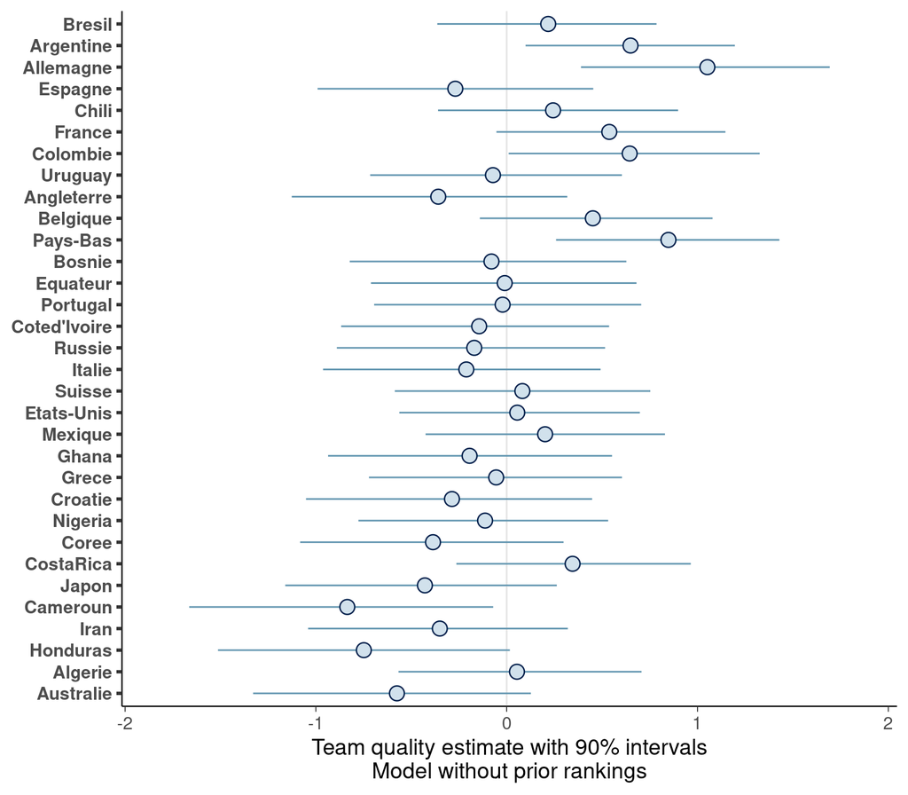

Figure 7

```r
fit_3_no_prior$draws("a") |>
  mcmc_intervals(prob = 0) +
  scale_y_discrete(labels = rev(teamnames), limits = rev) +
  labs(x = "Team quality estimate with 90% intervals\nModel without prior rankings")
#if (savefigs) ggsave(root("world_cup/figs","worldcup_2.pdf", height=7, width=8))
```

# 6 Discrete models and LOO-CV comparison

## 6.1 Discrete model with explicit latent z sampled

```r
model_discr_z <- cmdstan_model(stan_file = root("world_cup", "worldcup_discrete_z.stan"))
```

```r
print_stan_code(model_discr_z$code())
```

```stan
data {
  int N_teams;
  int N_games;
  vector[N_teams] prior_score;
  array[N_games] int team_1;
  array[N_games] int team_2;
  vector[N_games] score_1;
  vector[N_games] score_2;
  real df;
}
transformed data {
  vector[N_games] dif = score_1 - score_2;
}
parameters {
  vector[N_teams] alpha;
  real b;
  real<lower=0> sigma_a;
  real<lower=0> sigma_z;
  vector<lower=dif-0.5, upper=dif+0.5>[N_games] z;
}
transformed parameters {
  vector[N_teams] a = b * prior_score + sigma_a * alpha;
}
model {
  alpha ~ normal(0, 1);
  b ~ normal(0, 1);
  sigma_a ~ normal(0, 1);
  sigma_z ~ normal(0, 1);
  z ~ normal(a[team_1] - a[team_2], sigma_z);
}
generated quantities {
  vector[N_games] y_rep;
  vector[N_games] z_rep;
  vector[N_games] log_lik;
  for (n in 1:N_games) {
    z_rep[n] = normal_rng(a[team_1[n]] - a[team_2[n]], sigma_z);
    y_rep[n] = round(z_rep[n]);
    log_lik[n] = log_diff_exp(normal_lcdf(dif[n]+0.5 | a[team_1[n]] - a[team_2[n]], sigma_z), normal_lcdf(dif[n]-0.5 | a[team_1[n]] - a[team_2[n]], sigma_z));
  }
}
```

```r
fit_discr_z <- model_discr_z$sample(data = stan_data, refresh = 0)
loo_discr_z <- fit_discr_z$loo()
```

```r
fit_discr_z$summary(c("b", "sigma_a", "sigma_z"))
```

```
# A tibble: 3 × 10
  variable  mean median    sd   mad    q5   q95  rhat ess_bulk ess_tail
  <chr>    <dbl>  <dbl> <dbl> <dbl> <dbl> <dbl> <dbl>    <dbl>    <dbl>
1 b         1.1    1.1   0.32  0.31  0.53  1.6   1.0     3180.    2132.
2 sigma_a   0.51   0.52  0.23  0.22  0.12  0.87  1.0      768.    1035.
3 sigma_z   1.5    1.5   0.16  0.16  1.2   1.8   1.00    1531.    2207.
```

## 6.2 Discrete model with latent z integrated out

```r
model_discr <- cmdstan_model(stan_file = root("world_cup", "worldcup_discrete.stan"))
```

```r
print_stan_code(model_discr$code())
```

```stan
data {
  int N_teams;
  int N_games;
  vector[N_teams] prior_score;
  array[N_games] int team_1;
  array[N_games] int team_2;
  vector[N_games] score_1;
  vector[N_games] score_2;
}
transformed data {
  vector[N_games] dif = score_1 - score_2;
}
parameters {
  vector[N_teams] alpha;
  real b;
  real<lower=0> sigma_a;
  real<lower=0> sigma_z;
}
transformed parameters {
  vector[N_teams] a = b * prior_score + sigma_a * alpha;
}
model {
  alpha ~ normal(0, 1);
  b ~ normal(0, 1);
  sigma_a ~ normal(0, 1);
  sigma_z ~ normal(0, 1);
  for (n in 1:N_games) {
    target += log_diff_exp(normal_lcdf(dif[n]+0.5 | a[team_1[n]] - a[team_2[n]], sigma_z),
                           normal_lcdf(dif[n]-0.5 | a[team_1[n]] - a[team_2[n]], sigma_z));
  }
}
generated quantities {
  vector[N_games] y_rep;
  vector[N_games] z_rep;
  vector[N_games] log_lik;
  for (n in 1:N_games) {
    z_rep[n] = normal_rng(a[team_1[n]] - a[team_2[n]], sigma_z);
    y_rep[n] = round(z_rep[n]);
    log_lik[n] = log_diff_exp(normal_lcdf(dif[n]+0.5 | a[team_1[n]] - a[team_2[n]], sigma_z), normal_lcdf(dif[n]-0.5 | a[team_1[n]] - a[team_2[n]], sigma_z));
  }
}
```

```r
fit_discr <- model_discr$sample(data = stan_data, refresh = 0)
loo_discr <- fit_discr$loo(save_psis = TRUE)
```

```r
fit_discr$summary(c("a[1]", "a[32]", "b", "sigma_a", "sigma_z"))
```

```
# A tibble: 5 × 10
  variable  mean median    sd   mad    q5   q95  rhat ess_bulk ess_tail
  <chr>    <dbl>  <dbl> <dbl> <dbl> <dbl> <dbl> <dbl>    <dbl>    <dbl>
1 a[1]      0.49   0.51  0.44  0.44 -0.30  1.1    1.0    3127.    3362.
2 a[32]    -1.0   -1.0   0.48  0.45 -1.8  -0.27   1.0    5880.    3316.
3 b         1.1    1.1   0.32  0.30  0.54  1.6    1.0    3312.    2552.
4 sigma_a   0.52   0.52  0.22  0.21  0.13  0.87   1.0    1025.     974.
5 sigma_z   1.5    1.5   0.16  0.16  1.2   1.8    1.0    1790.    2542.
```

## 6.3 Discrete model with no power score

```r
model_discr_nopower <- cmdstan_model(stan_file = root("world_cup", "worldcup_discrete_nopower.stan"))
```

```r
print_stan_code(model_discr_nopower$code())
```

```stan
data {
  int N_teams;
  int N_games;
  array[N_games] int team_1;
  array[N_games] int team_2;
  vector[N_games] score_1;
  vector[N_games] score_2;
}
transformed data {
  vector[N_games] dif = score_1 - score_2;
}
parameters {
  vector[N_teams] alpha;
  real<lower=0> sigma_a;
  real<lower=0> sigma_z;
}
transformed parameters {
  vector[N_teams] a = sigma_a * alpha;
}
model {
  alpha ~ normal(0, 1);
  sigma_a ~ normal(0, 1);
  sigma_z ~ normal(0, 1);
  for (n in 1:N_games) {
    target += log_diff_exp(normal_lcdf(dif[n]+0.5 | a[team_1[n]] - a[team_2[n]], sigma_z),
                           normal_lcdf(dif[n]-0.5 | a[team_1[n]] - a[team_2[n]], sigma_z));
  }
}
generated quantities {
  vector[N_games] y_rep;
  vector[N_games] z_rep;
  vector[N_games] log_lik;
  for (n in 1:N_games) {
    real a_dif_n = a[team_1[n]] - a[team_2[n]];
    z_rep[n] = normal_rng(a_dif_n, sigma_z);
    y_rep[n] = round(z_rep[n]);
    log_lik[n] = log_diff_exp(normal_lcdf(dif[n]+0.5 | a_dif_n, sigma_z),
                              normal_lcdf(dif[n]-0.5 | a_dif_n, sigma_z));
  }
}
```

```r
fit_discr_nopower <- model_discr_nopower$sample(data = stan_data, refresh = 0)
loo_discr_nopower <- fit_discr_nopower$loo()
```

```r
fit_discr_nopower$summary(c("a[1]", "a[32]", "sigma_a", "sigma_z"))
```

```
# A tibble: 4 × 10
  variable   mean median    sd   mad    q5   q95  rhat ess_bulk ess_tail
  <chr>     <dbl>  <dbl> <dbl> <dbl> <dbl> <dbl> <dbl>    <dbl>    <dbl>
1 a[1]     -0.062 -0.050  0.48  0.47 -0.85  0.70   1.0    5679.    3024.
2 a[32]    -0.71  -0.67   0.66  0.66 -1.9   0.30   1.0    2996.    3039.
3 sigma_a   0.76   0.76   0.24  0.22  0.35  1.1    1.0     888.     553.
4 sigma_z   1.5    1.5    0.19  0.19  1.2   1.8    1.0    1388.    1521.
```

## 6.4 Discrete model with power score only

```r
model_discr_poweronly <- cmdstan_model(stan_file = root("world_cup", "worldcup_discrete_poweronly.stan"))
```

```r
print_stan_code(model_discr_poweronly$code())
```

```stan
data {
  int N_teams;
  int N_games;
  vector[N_teams] prior_score;
  array[N_games] int team_1;
  array[N_games] int team_2;
  vector[N_games] score_1;
  vector[N_games] score_2;
}
transformed data {
  vector[N_games] dif = score_1 - score_2;
}
parameters {
  real b0;
  real b;
  real<lower=0> sigma_z;
}
transformed parameters {
  vector[N_teams] a = b0 + b * prior_score;
}
model {
  b0 ~ normal(0, 1);
  b ~ normal(0, 1);
  sigma_z ~ normal(0, 1);
  for (n in 1:N_games) {
    target += log_diff_exp(normal_lcdf(dif[n]+0.5 | a[team_1[n]] - a[team_2[n]], sigma_z),
                           normal_lcdf(dif[n]-0.5 | a[team_1[n]] - a[team_2[n]], sigma_z));
  }
}
generated quantities {
  vector[N_games] y_rep;
  vector[N_games] z_rep;
  vector[N_games] log_lik;
  for (n in 1:N_games) {
    z_rep[n] = normal_rng(a[team_1[n]] - a[team_2[n]], sigma_z);
    y_rep[n] = round(z_rep[n]);
    log_lik[n] = log_diff_exp(normal_lcdf(dif[n]+0.5 | a[team_1[n]] - a[team_2[n]], sigma_z), normal_lcdf(dif[n]-0.5 | a[team_1[n]] - a[team_2[n]], sigma_z));
  }
}
```

```r
fit_discr_poweronly <- model_discr_poweronly$sample(data = stan_data, refresh = 0)
loo_discr_poweronly <- fit_discr_poweronly$loo()
```

```r
fit_discr_poweronly$summary(c("b0", "b", "sigma_z"))
```

```
# A tibble: 3 × 10
  variable    mean median    sd   mad    q5   q95  rhat ess_bulk ess_tail
  <chr>      <dbl>  <dbl> <dbl> <dbl> <dbl> <dbl> <dbl>    <dbl>    <dbl>
1 b0       -0.0021  0.012  0.96  0.96 -1.6    1.6   1.0    3990.    2620.
2 b         1.1     1.1    0.27  0.27  0.64   1.5   1.0    4150.    3110.
3 sigma_z   1.6     1.6    0.14  0.14  1.4    1.9   1.0    3527.    3066.
```

## 6.5 Discrete model with no power score and pooled effect

```r
model_discr_pool <- cmdstan_model(stan_file = root("world_cup", "worldcup_discrete_pooled.stan"))
```

```r
print_stan_code(model_discr_pool$code())
```

```stan
data {
  int N_teams;
  int N_games;
  vector[N_teams] prior_score;
  array[N_games] int team_1;
  array[N_games] int team_2;
  vector[N_games] score_1;
  vector[N_games] score_2;
}
transformed data {
  vector[N_games] dif = score_1 - score_2;
}
parameters {
  real mu_z;
  real<lower=0> sigma_z;
}
model {
  mu_z ~ normal(0, 1);
  sigma_z ~ normal(0, 1);
  for (n in 1:N_games) {
    target += log_diff_exp(normal_lcdf(dif[n]+0.5 | mu_z, sigma_z),
                           normal_lcdf(dif[n]-0.5 | mu_z, sigma_z));
  }
}
generated quantities {
  vector[N_games] y_rep;
  vector[N_games] z_rep;
  vector[N_games] log_lik;
  for (n in 1:N_games) {
    z_rep[n] = normal_rng(mu_z, sigma_z);
    y_rep[n] = round(z_rep[n]);
    log_lik[n] = log_diff_exp(normal_lcdf(dif[n]+0.5 | mu_z, sigma_z), normal_lcdf(dif[n]-0.5 | mu_z, sigma_z));
  }
}
```

```r
fit_discr_pool <- model_discr_pool$sample(data = stan_data, refresh = 0)
loo_discr_pool <- fit_discr_pool$loo()
```

```r
fit_discr_pool$summary(c("mu_z","sigma_z"))
```

```
# A tibble: 2 × 10
  variable  mean median    sd   mad    q5   q95  rhat ess_bulk ess_tail
  <chr>    <dbl>  <dbl> <dbl> <dbl> <dbl> <dbl> <dbl>    <dbl>    <dbl>
1 mu_z     -0.13  -0.13  0.23  0.23 -0.51  0.25   1.0    2964.    2346.
2 sigma_z   1.8    1.8   0.17  0.16  1.6   2.1    1.0    3217.    2602.
```

## 6.6 Model comparison

Now that we have implemented discrete model, we compare various models with or without different components. Hierarchical model with power score is the best, but not much better than power score only model or hierarchical model without power score. Clearly the power score and the score differences are providing similar information. Looking at the posterior we do see that using them both, does decrease posterior uncertainty, but as the match outcomes still have significant randomness the difference in predictive performance is small.

```r
loo_compare(
  list(
    "Hier. w power score" = loo_discr,
    "Power score only" = loo_discr_poweronly,
    "Hier. w/o power score" = loo_discr_nopower,
    "Pooled w/o power score" = loo_discr_pool
  )
)
```

```
                  model elpd_diff se_diff p_worse diag_diff      diag_elpd
    Hier. w power score       0.0     0.0      NA           2 k_psis > 0.7
       Power score only      -1.3     1.8    0.78   N < 100
  Hier. w/o power score      -3.3     2.8    0.89   N < 100 1 k_psis > 0.7
 Pooled w/o power score      -8.4     3.4    0.99   N < 100
```

# 7 Discretizing continuous models

## 7.1 Continuous model with log predictive probability using midpoint rule

```r
model_cont_midp <- cmdstan_model(stan_file = root("world_cup", "worldcup_continuous_midpoint_ll.stan"))
```

```r
print_stan_code(model_cont_midp$code())
```

```stan
data {
  int N_teams;
  int N_games;
  vector[N_teams] prior_score;
  array[N_games] int team_1;
  array[N_games] int team_2;
  vector[N_games] score_1;
  vector[N_games] score_2;
}
transformed data {
  vector[N_games] dif = score_1 - score_2;
}
parameters {
  vector[N_teams] alpha;
  real b;
  real<lower=0> sigma_a;
  real<lower=0> sigma_y;
}
transformed parameters {
  vector[N_teams] a = b * prior_score + sigma_a * alpha;
}
model {
  alpha ~ normal(0, 1);
  b ~ normal(0, 1);
  sigma_a ~ normal(0, 1);
  sigma_y ~ normal(0, 1);
  dif ~ normal(a[team_1] - a[team_2], sigma_y);
}
generated quantities {
  vector[N_games] y_rep;
  vector[N_games] log_lik;
  for (n in 1:N_games) {
    y_rep[n] = normal_rng(a[team_1[n]] - a[team_2[n]], sigma_y);
    log_lik[n] = normal_lpdf(dif[n] | a[team_1[n]] - a[team_2[n]], sigma_y);
  }
}
```

```r
fit_cont_midp <- model_cont_midp$sample(data = stan_data, refresh = 0)
loo_cont_midp <- fit_cont_midp$loo()
```

```r
fit_cont_midp$summary(c("a[1]", "a[32]", "b", "sigma_a", "sigma_y"))
```

```
# A tibble: 5 × 10
  variable  mean median    sd   mad    q5   q95  rhat ess_bulk ess_tail
  <chr>    <dbl>  <dbl> <dbl> <dbl> <dbl> <dbl> <dbl>    <dbl>    <dbl>
1 a[1]      0.48   0.51  0.45  0.46 -0.28  1.2    1.0    3280.    3344.
2 a[32]    -1.0   -0.99  0.49  0.46 -1.9  -0.25   1.0    5860.    2903.
3 b         1.1    1.1   0.31  0.31  0.59  1.6    1.0    4527.    3015.
4 sigma_a   0.51   0.52  0.22  0.22  0.12  0.87   1.0     877.    1252.
5 sigma_y   1.5    1.5   0.16  0.16  1.3   1.8    1.0    1952.    2682.
```

## 7.2 Continuous model with log predictive probability using exact integration

```r
model_cont <- cmdstan_model(stan_file = root("world_cup", "worldcup_continuous.stan"))
```

```r
print_stan_code(model_cont$code())
```

```stan
data {
  int N_teams;
  int N_games;
  vector[N_teams] prior_score;
  array[N_games] int team_1;
  array[N_games] int team_2;
  vector[N_games] score_1;
  vector[N_games] score_2;
}
transformed data {
  vector[N_games] dif = score_1 - score_2;
}
parameters {
  vector[N_teams] alpha;     // latent team abilities
  real b;                    // prior weight
  real<lower=0> sigma_a;     // scale of ability prior distribution
  real<lower=0> sigma_y;     // scale of score difference distribution
}
transformed parameters {
  // team abilities as weighted sum of prior score and latent team ability
  vector[N_teams] a = b * prior_score + sigma_a * alpha;
}
model {
  alpha ~ normal(0, 1);
  b ~ normal(0, 1);
  sigma_a ~ normal(0, 1);
  sigma_y ~ normal(0, 1);
  dif ~ normal(a[team_1] - a[team_2], sigma_y);
}
generated quantities {
  vector[N_games] y_rep;
  vector[N_games] log_lik;
  for (n in 1:N_games) {
    y_rep[n] = normal_rng(a[team_1[n]] - a[team_2[n]], sigma_y);
    log_lik[n] = log_diff_exp(normal_lcdf(dif[n]+0.5 | a[team_1[n]] - a[team_2[n]], sigma_y), normal_lcdf(dif[n]-0.5 | a[team_1[n]] - a[team_2[n]], sigma_y));
  }
}
```

```r
fit_cont <- model_cont$sample(data = stan_data, refresh = 0)
loo_cont <- fit_cont$loo()
```

```r
fit_cont$summary(c("a[1]", "a[32]", "b", "sigma_a", "sigma_y"))
```

```
# A tibble: 5 × 10
  variable  mean median    sd   mad    q5   q95  rhat ess_bulk ess_tail
  <chr>    <dbl>  <dbl> <dbl> <dbl> <dbl> <dbl> <dbl>    <dbl>    <dbl>
1 a[1]      0.48   0.50  0.45  0.46 -0.28  1.2    1.0    2837.    2898.
2 a[32]    -1.0   -1.0   0.48  0.44 -1.8  -0.26   1.0    5976.    3588.
3 b         1.1    1.1   0.31  0.31  0.57  1.6    1.0    3725.    2819.
4 sigma_a   0.51   0.52  0.22  0.22  0.12  0.87   1.0     864.    1031.
5 sigma_y   1.5    1.5   0.16  0.17  1.3   1.8    1.0    1818.    2354.
```

## 7.3 Model comparison

The elpd_diff’s between models are small enough to be caused by Monte Carlo variation

```r
loo_compare(
  list(
    "Discrete model" = loo_discr,
    "Continuous + midpoint log_lik" = loo_cont_midp,
    "Continuous model" = loo_cont
  )
)
```

```
                         model elpd_diff se_diff p_worse diag_diff
              Continuous model       0.0     0.0      NA
                Discrete model      -0.6     0.4    0.95   N < 100
 Continuous + midpoint log_lik      -0.6     0.3    0.96   N < 100
      diag_elpd

 2 k_psis > 0.7
```

## 7.4 More discretized continuous models

Continuous sqrt model with log predictive probability using midpoint rule and no Jacobian

```r
model_sqrt_cont_noj <- cmdstan_model(stan_file = root("world_cup", "worldcup_sqrt_continuous_nojacobian.stan"))
```

```r
print_stan_code(model_sqrt_cont_noj$code())
```

```stan
/* The error in the transformed data block has been fixed */
data {
  int N_teams;
  int N_games;
  vector[N_teams] prior_score;
  array[N_games] int team_1;
  array[N_games] int team_2;
  vector[N_games] score_1;
  vector[N_games] score_2;
  real df;
}
transformed data {
  vector[N_games] dif = score_1 - score_2;
  vector[N_games] sqrt_dif;
  for (i in 1:N_games){
    sqrt_dif[i] = 2 * (step(dif[i]) - 0.5) * sqrt(abs(dif[i]));
  }
}
parameters {
  vector[N_teams] alpha;
  real b;
  real<lower=0> sigma_a;
  real<lower=0> sigma_y;
}
transformed parameters {
  vector[N_teams] a = b * prior_score + sigma_a * alpha;
}
model {
  alpha ~ normal(0, 1);
  b ~ normal(0, 1);
  sigma_a ~ normal(0, 1);
  sigma_y ~ normal(0, 1);
  sqrt_dif ~ normal(a[team_1] - a[team_2], sigma_y);
}
generated quantities {
  vector[N_games] y_rep;
  vector[N_games] y_rep_original_scale;
  vector[N_games] log_lik;
  real lprior;
  for (n in 1:N_games) {
    y_rep[n] = normal_rng(a[team_1[n]] - a[team_2[n]], sigma_y);
    log_lik[n] = normal_lpdf(sqrt_dif[n] | a[team_1[n]] - a[team_2[n]], sigma_y);
  }
  y_rep_original_scale = y_rep .* abs(y_rep);
  lprior = normal_lpdf(b | 0, 1) +
           normal_lpdf(sigma_a | 0, 1) +
           normal_lpdf(sigma_y | 0, 1);
  real round15 = round(1.5);
  real round25 = round(2.5);
}
```

```r
fit_sqrt_cont_noj <- model_sqrt_cont_noj$sample(data = stan_data, refresh = 0)
loo_sqrt_cont_noj <- fit_sqrt_cont_noj$loo()
```

```r
fit_sqrt_cont_noj$summary(c("a[1]", "a[32]", "b", "sigma_a", "sigma_y"))
```

```
# A tibble: 5 × 10
  variable  mean median    sd   mad     q5   q95  rhat ess_bulk ess_tail
  <chr>    <dbl>  <dbl> <dbl> <dbl>  <dbl> <dbl> <dbl>    <dbl>    <dbl>
1 a[1]      0.49   0.50  0.27  0.27  0.015  0.90   1.0    3447.    3115.
2 a[32]    -0.74  -0.73  0.32  0.30 -1.3   -0.23   1.0    5175.    3116.
3 b         0.82   0.83  0.21  0.20  0.48   1.2    1.0    3790.    2541.
4 sigma_a   0.34   0.34  0.15  0.14  0.071  0.57   1.0     802.     788.
5 sigma_y   0.92   0.92  0.10  0.10  0.76   1.1    1.0    1551.    2411.
```

Continuous sqrt model with log predictive probability using midpoint rule and Jacobian is not possible as Jacobian is infinite for midpoint 0 Continuous sqrt model with log predictive probability using Jacobian and quadrature integration

```r
model_sqrt_cont <- cmdstan_model(stan_file = root("world_cup", "worldcup_sqrt_continuous.stan"))
```

```r
print_stan_code(model_sqrt_cont$code())
```

```stan
/* The error in the transformed data block has been fixed */
functions {
  real integrand(real z, real notused, array[] real theta,
               array[] real X_i, array[] int y_i) {
    real sigma_y = theta[1];
    real a_diff = theta[2];
    real sqrt_z = 2 * (step(z) - 0.5) * sqrt(abs(z));
    real p = exp(normal_lpdf(sqrt_z | a_diff, sigma_y) - log(abs(z))/2 -log(2));
    return (is_inf(p) || is_nan(p)) ? 0 : p;
  }
}

data {
  int N_teams;
  int N_games;
  vector[N_teams] prior_score;
  array[N_games] int team_1;
  array[N_games] int team_2;
  vector[N_games] score_1;
  vector[N_games] score_2;
  real df;
}
transformed data {
  vector[N_games] dif = score_1 - score_2;
  vector[N_games] sqrt_dif;
  for (i in 1:N_games){
    sqrt_dif[i] = 2 * (step(dif[i]) - 0.5) * sqrt(abs(dif[i]));
  }
}
parameters {
  vector[N_teams] alpha;
  real b;
  real<lower=0> sigma_a;
  real<lower=0> sigma_y;
}
transformed parameters {
  vector[N_teams] a = b * prior_score + sigma_a * alpha;
}
model {
  alpha ~ normal(0, 1);
  b ~ normal(0, 1);
  sigma_a ~ normal(0, 1);
  sigma_y ~ normal(0, 1);
  sqrt_dif ~ normal(a[team_1] - a[team_2], sigma_y);
}
generated quantities {
  vector[N_games] y_rep;
  vector[N_games] y_rep_original_scale;
  vector[N_games] log_lik;
  real lprior;
  for (n in 1:N_games) {
    y_rep[n] = normal_rng(a[team_1[n]] - a[team_2[n]], sigma_y);
    log_lik[n] = (dif[n] == 0)
    ? log(integrate_1d(integrand,
                              -0.5,
                              0,
                              append_array({sigma_y}, {a[team_1[n]] - a[team_2[n]]}),
                  {0}, // not used, but an empty array not allowed
                  {0}, // not used, but an empty array not allowed
                  1e-6) +
      integrate_1d(integrand,
                              0,
                              0.5,
                              append_array({sigma_y}, {a[team_1[n]] - a[team_2[n]]}),
                  {0}, // not used, but an empty array not allowed
                  {0}, // not used, but an empty array not allowed
                  1e-6))
    : log(integrate_1d(integrand,
                              dif[n]-0.5,
                              dif[n]+0.5,
                              append_array({sigma_y}, {a[team_1[n]] - a[team_2[n]]}),
                  {0}, // not used, but an empty array not allowed
                  {0}, // not used, but an empty array not allowed
                  1e-6));
  }
  y_rep_original_scale = y_rep .* abs(y_rep);
  lprior = normal_lpdf(b | 0, 1) +
           normal_lpdf(sigma_a | 0, 1) +
           normal_lpdf(sigma_y | 0, 1);
}
```

```r
fit_sqrt_cont <- model_sqrt_cont$sample(data = stan_data, refresh = 0)
loo_sqrt_cont <- fit_sqrt_cont$loo(save_psis = TRUE)
```

```r
fit_sqrt_cont$summary(c("a[1]", "a[32]", "b", "sigma_a", "sigma_y"))
```

```
# A tibble: 5 × 10
  variable  mean median    sd   mad     q5   q95  rhat ess_bulk ess_tail
  <chr>    <dbl>  <dbl> <dbl> <dbl>  <dbl> <dbl> <dbl>    <dbl>    <dbl>
1 a[1]      0.48   0.49  0.27  0.27  0.014  0.90  1.0     4421.    2790.
2 a[32]    -0.74  -0.73  0.32  0.29 -1.3   -0.24  1.00    6450.    3272.
3 b         0.83   0.83  0.21  0.20  0.49   1.2   1.0     3810.    2938.
4 sigma_a   0.34   0.34  0.14  0.14  0.097  0.57  1.0      944.    1095.
5 sigma_y   0.92   0.91  0.10  0.10  0.76   1.1   1.0     1841.    2516.
```

Discrete sqrt model with log predictive probability using Jacobian and quadrature integration. The sampling is slow as the quadrature integration is done at each HMC/NUTS leapfrog step.

```r
model_sqrt_discr <- cmdstan_model(stan_file = root("world_cup", "worldcup_sqrt_discrete.stan"))
```

```r
print_stan_code(model_sqrt_discr$code())
```

```stan
/* The error in the transformed data block has been fixed */
functions {
  real integrand(real z, real notused, array[] real theta,
               array[] real X_i, array[] int y_i) {
    real sigma_y = theta[1];
    real a_diff = theta[2];
    real sqrt_z = 2 * (step(z) - 0.5) * sqrt(abs(z));
    real p = exp(normal_lpdf(sqrt_z | a_diff, sigma_y) - log(abs(z))/2 -log(2));
    return (is_inf(p) || is_nan(p)) ? 0 : p;
  }
}

data {
  int N_teams;
  int N_games;
  vector[N_teams] prior_score;
  array[N_games] int team_1;
  array[N_games] int team_2;
  vector[N_games] score_1;
  vector[N_games] score_2;
  real df;
}
transformed data {
  vector[N_games] dif = score_1 - score_2;
  vector[N_games] sqrt_dif;
  for (i in 1:N_games){
    sqrt_dif[i] = 2 * (step(dif[i]) - 0.5) * sqrt(abs(dif[i]));
  }
}
parameters {
  vector[N_teams] alpha;
  real b;
  real<lower=0> sigma_a;
  real<lower=0> sigma_y;
}
transformed parameters {
  vector[N_teams] a = b * prior_score + sigma_a * alpha;
}
model {
  alpha ~ normal(0, 1);
  b ~ normal(0, 1);
  sigma_a ~ normal(0, 1);
  sigma_y ~ normal(0, 1);
  for (n in 1:N_games) {
    target += (dif[n] == 0)
    ? log(integrate_1d(integrand,
                              -0.5,
                              0,
                              append_array(append_array({sigma_y}, {a[team_1[n]] - a[team_2[n]]}), {df}),
                  {0}, // not used, but an empty array not allowed
                  {0}, // not used, but an empty array not allowed
                  1e-5) +
      integrate_1d(integrand,
                              0,
                              0.5,
                              append_array(append_array({sigma_y}, {a[team_1[n]] - a[team_2[n]]}), {df}),
                  {0}, // not used, but an empty array not allowed
                  {0}, // not used, but an empty array not allowed
                  1e-5))
    : log(integrate_1d(integrand,
                              dif[n]-0.5,
                              dif[n]+0.5,
                              append_array(append_array({sigma_y}, {a[team_1[n]] - a[team_2[n]]}), {df}),
                  {0}, // not used, but an empty array not allowed
                  {0}, // not used, but an empty array not allowed
                  1e-5));
//                integrate_1d_reltol));
  }

}
generated quantities {
  vector[N_games] y_rep;
  vector[N_games] y_rep_original_scale;
  vector[N_games] log_lik;
  real lprior;
  for (n in 1:N_games) {
    y_rep[n] = normal_rng(a[team_1[n]] - a[team_2[n]], sigma_y);
    // log_lik[n] = student_t_lpdf(sqrt_dif[n] | df, a[team_1[n]] - a[team_2[n]], sigma_y) + (dif[n]==0 ? 0 : -log(abs(dif[n]))/2 -log(2));
    log_lik[n] = (dif[n] == 0)
    ? log(integrate_1d(integrand,
                              -0.5,
                              0,
                              append_array({sigma_y}, {a[team_1[n]] - a[team_2[n]]}),
                  {0}, // not used, but an empty array not allowed
                  {0}, // not used, but an empty array not allowed
                  1e-6) +
      integrate_1d(integrand,
                              0,
                              0.5,
                              append_array({sigma_y}, {a[team_1[n]] - a[team_2[n]]}),
                  {0}, // not used, but an empty array not allowed
                  {0}, // not used, but an empty array not allowed
                  1e-6))
    : log(integrate_1d(integrand,
                              dif[n]-0.5,
                              dif[n]+0.5,
                              append_array({sigma_y}, {a[team_1[n]] - a[team_2[n]]}),
                  {0}, // not used, but an empty array not allowed
                  {0}, // not used, but an empty array not allowed
                  1e-6));
//                integrate_1d_reltol));
  }
  y_rep_original_scale = y_rep .* abs(y_rep);
  lprior = normal_lpdf(b | 0, 1) +
           normal_lpdf(sigma_a | 0, 1) +
           normal_lpdf(sigma_y | 0, 1);
}
```

```r
fit_sqrt_discr <- model_sqrt_discr$sample(data = stan_data, refresh = 0)
loo_sqrt_discr <- fit_sqrt_discr$loo()
```

```r
fit_sqrt_discr$summary(c("a[1]", "a[32]", "b", "sigma_a", "sigma_y"))
```

```
# A tibble: 5 × 10
  variable  mean median    sd   mad      q5   q95  rhat ess_bulk ess_tail
  <chr>    <dbl>  <dbl> <dbl> <dbl>   <dbl> <dbl> <dbl>    <dbl>    <dbl>
1 a[1]      0.48   0.49  0.28  0.27 -0.0067  0.91   1.0    4459.    3367.
2 a[32]    -0.74  -0.73  0.32  0.29 -1.3    -0.23   1.0    5592.    3292.
3 b         0.83   0.83  0.20  0.20  0.49    1.2    1.0    3630.    2925.
4 sigma_a   0.36   0.36  0.15  0.14  0.091   0.60   1.0     840.     799.
5 sigma_y   0.90   0.89  0.11  0.11  0.73    1.1    1.0    1502.    2431.
```

## 7.5 Model comparison

Without taking Jacobian into account, the continuous model for square root of score difference looks like the best

```r
loo_compare(
  list(
    "Discrete" = loo_discr,
    "Discrete sqrt" = loo_sqrt_discr,
    "Cont-sqrt + midp, -Jacobian" = loo_sqrt_cont_noj
  )
)
```

```
                       model elpd_diff se_diff p_worse diag_diff      diag_elpd
 Cont-sqrt + midp, -Jacobian       0.0     0.0      NA           1 k_psis > 0.7
                    Discrete     -32.5     5.2    1.00   N < 100 2 k_psis > 0.7
               Discrete sqrt     -40.3     4.3    1.00   N < 100
```

Taking Jacobian into account, the square root models are worse, and the difference between continuous and discrete square root model is small enough to be explained by Monte Carlo variation.

```r
loo_compare(
  list(
    "Discrete" = loo_discr,
    "Discrete sqrt" = loo_sqrt_discr,
    "Continuous sqrt +Jacobian" = loo_sqrt_cont
  )
)
```

```
                     model elpd_diff se_diff p_worse diag_diff      diag_elpd
                  Discrete       0.0     0.0      NA           2 k_psis > 0.7
 Continuous sqrt +Jacobian      -7.2     5.5    0.91   N < 100 2 k_psis > 0.7
             Discrete sqrt      -7.8     5.4    0.93   N < 100
```

## 7.6 LOO-CV predictive checking

LOO-CV predictive checking with LOO-PIT for the discrete model looks fine

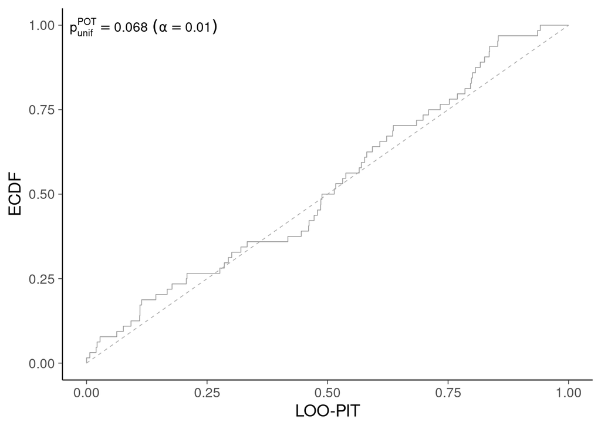

```r
ppc_loo_pit_ecdf(
  y = stan_data$score_1 - stan_data$score_2,
  yrep = fit_discr$draws(format = "matrix", variables = "y_rep"),
  psis_object = loo_discr$psis_object,
  method = "correlated"
)
```

LOO-CV predictive checking for the continuous model indicates slight miscalibration with too many low PIT values (left tail of the predictive distribution is shorter than expected)

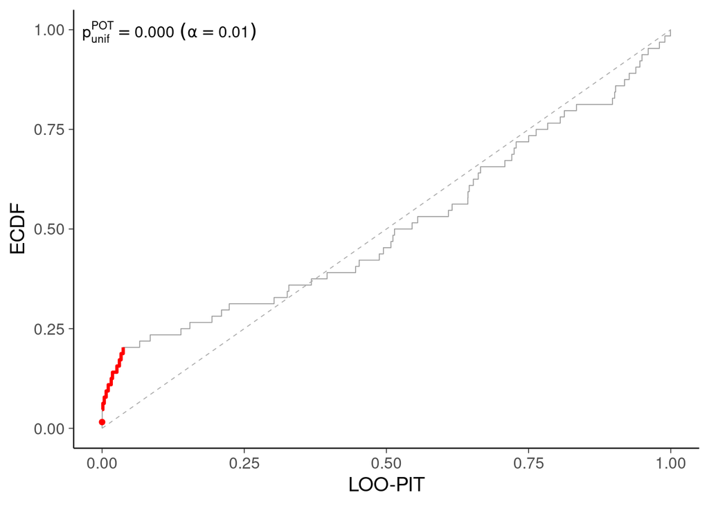

```r
ppc_loo_pit_ecdf(
  y = stan_data$score_1 - stan_data$score_2,
  yrep = fit_sqrt_cont$draws(format = "matrix", variables = "y_rep"),
  psis_object = loo_sqrt_cont$psis_object,
  method = "correlated"
)
```

# 8 Bivariate Poisson and Poisson difference models

Bivariate Poisson model is commonly used for football scores (Karlis and Ntzoufras 2003). If we care only about the score difference we can also use Poisson difference model (Karlis and Ntzoufras 2003).

```r
model_bipois <- cmdstan_model(stan_file = root("world_cup", "worldcup_bivariate_poisson.stan"))
```

```r
print_stan_code(model_bipois$code())
```

```stan
functions {
 real bivariate_poisson_log_lpmf_(int score1, int score2,
                                  real log_lambda_1, real log_lambda_2, real log_lambda_3) {
    // bivariate Poisson with lambda_3 presenting the correlation
    // e.g. Karlis and Ntzoufras (2003). Analysis of sports data by using bivariate Poisson models
    int m = min(score1, score2);
    vector[m + 1] log_terms;
    for (z in 0 : m) {
      int r1 = score1 - z;
      int r2 = score2 - z;
      log_terms[z + 1] = r1 * log_lambda_1 - lgamma(r1 + 1)
                         + r2 * log_lambda_2 - lgamma(r2 + 1)
                         + z * log_lambda_3 - lgamma(z + 1);
    }
    return -exp(log_lambda_1) - exp(log_lambda_2) - exp(log_lambda_3) + log_sum_exp(log_terms);
}
  real bivariate_poisson_log_lpmf(array[,] int score,
                                  vector log_lambda_1, vector log_lambda_2, real log_lambda_3) {
    // bivariate Poisson lpmf for array[2,N] scores
    array[2] int score_dims = dims(score);
    real total = 0;
    for (i in 1:score_dims[2]) {
      total += bivariate_poisson_log_lpmf_(score[1,i], score[2,i],
                                           log_lambda_1[i], log_lambda_2[i], log_lambda_3);
    }
    return total;
  }
  real bivariate_poisson_log_lpmf(array[] int score,
                                  real log_lambda_1, real log_lambda_2, real log_lambda_3) {
    // bivariate Poisson lpmf for array[2] scores
    return bivariate_poisson_log_lpmf_(score[1], score[2],
                                       log_lambda_1, log_lambda_2, log_lambda_3);
  }
}
data {
  int N_teams;
  int N_games;
  vector[N_teams] prior_score;
  array[N_games] int team_1;
  array[N_games] int team_2;
  array[N_games] int score_1;
  array[N_games] int score_2;
}
parameters {
  vector[N_teams] z_o;
  vector[N_teams] z_d;
  real a;
  real b_o;
  real b_d;
  real c;
  real<lower=0> sigma_o;
  real<lower=0> sigma_d;
}
transformed parameters {
  vector[N_teams] o = b_o * prior_score + sigma_o * z_o;
  vector[N_teams] d = b_d * prior_score + sigma_d * z_d;
}
model {
  z_o ~ normal(0, 1);
  z_d ~ normal(0, 1);
  b_o ~ normal(0, 1);
  b_d ~ normal(0, 1);
  a ~ normal(0, 1);
  // prior centered on 1991–1992 Italian serie A data estimate as reported by
  // Karlis and Ntzoufras (2003) and very wide prior around.
  c ~ normal(-1.5, 20);
  sigma_o ~ normal(0, 1);
  sigma_d ~ normal(0, 1);
  {score_1, score_2} ~ bivariate_poisson_log(a + o[team_1] + d[team_2],
                                             a + o[team_2] + d[team_1],
                         c);
}
generated quantities {
  array[N_games] int y_rep;
  array[N_games] int score_1_rep;
  array[N_games] int score_2_rep;
  vector[N_games] log_lik;
  vector[N_games] log_lik2;
  for (n in 1:N_games) {
    int score_c = poisson_log_rng(c);
    score_1_rep[n] = poisson_log_rng(a + o[team_1[n]] + d[team_2[n]]) + score_c;
    score_2_rep[n] = poisson_log_rng(a + o[team_2[n]] + d[team_1[n]]) + score_c;
    y_rep[n] = score_1_rep[n] - score_2_rep[n];
    // log probability using the bivariate Poisson lpmf
    log_lik2[n] = bivariate_poisson_log_lpmf({score_1[n], score_2[n]} |
                                        a + o[team_1[n]] + d[team_2[n]],
                                        a + o[team_2[n]] + d[team_1[n]],
                    c);
    // log probability using the Poisson difference lpmf
    // note that lambda3 cancels out in the difference
    int dif = score_1[n] - score_2[n];
    real l1 = exp(o[team_1[n]] + d[team_2[n]]);
    real l2 = exp(o[team_2[n]] + d[team_1[n]]);
    log_lik[n] = -(l1 + l2) + (log(l1) - log(l2))*(dif/2.0) +
                 log(modified_bessel_first_kind(dif, 2.0*sqrt(l1*l2)));
  }
}
```

```r
fit_bipois <- model_bipois$sample(data = stan_data, refresh = 0, adapt_delta = 0.95)
```

```r
fit_bipois$summary(c("a","o[1]","o[32]","d[1]","d[32]","b_o","b_d","sigma_o","sigma_d"))
```

```
# A tibble: 9 × 10
  variable   mean median    sd   mad     q5    q95  rhat ess_bulk ess_tail
  <chr>     <dbl>  <dbl> <dbl> <dbl>  <dbl>  <dbl> <dbl>    <dbl>    <dbl>
1 a         0.056  0.11   0.23  0.19 -0.41   0.33    1.0     558.     865.
2 o[1]      0.41   0.41   0.22  0.21  0.050  0.78    1.0    1673.    1678.
3 o[32]    -0.42  -0.41   0.28  0.23 -0.89   0.014   1.0    1579.    1893.
4 d[1]     -0.032 -0.056  0.31  0.33 -0.49   0.53    1.0    1364.    2459.
5 d[32]     0.46   0.44   0.27  0.25  0.027  0.90    1.0    3558.    2615.
6 b_o       0.53   0.52   0.23  0.23  0.19   0.94    1.0    1057.    1060.
7 b_d      -0.45  -0.44   0.21  0.19 -0.78  -0.11    1.0    1219.     767.
8 sigma_o   0.18   0.16   0.13  0.13  0.016  0.41    1.0     909.    1365.
9 sigma_d   0.30   0.29   0.17  0.17  0.041  0.61    1.0     561.    1146.
```

```r
(loo_bipois <- fit_bipois$loo(save_psis = TRUE))
```

```
Computed from 4000 by 64 log-likelihood matrix.

         Estimate   SE
elpd_loo   -124.7  8.1
p_loo        12.9  3.2
looic       249.4 16.3
------
MCSE of elpd_loo is NA.
MCSE and ESS estimates assume MCMC draws (r_eff in [0.2, 1.2]).

Pareto k diagnostic values:
                         Count Pct.    Min. ESS
(-Inf, 0.7]   (good)     57    89.1%   175
   (0.7, 1]   (bad)       6     9.4%   <NA>
   (1, Inf)   (very bad)  1     1.6%   <NA>
See help('pareto-k-diagnostic') for details.
```

```r
model_poisdif <- cmdstan_model(stan_file = root("world_cup", "worldcup_poisson_difference.stan"))
```

```r
print_stan_code(model_poisdif$code())
```

```stan
data {
  int N_teams;
  int N_games;
  vector[N_teams] prior_score;
  array[N_games] int team_1;
  array[N_games] int team_2;
  vector[N_games] score_1;
  vector[N_games] score_2;
}
transformed data {
  vector[N_games] dif = score_1 - score_2;
}
parameters {
  vector[N_teams] alpha;
  real b;
  real<lower=0> sigma_a;
}
transformed parameters {
  vector[N_teams] a = b * prior_score + sigma_a * alpha;
}
model {
  alpha ~ normal(0, 1);
  b ~ normal(0, 1);
  sigma_a ~ normal(0, 1);
  for (n in 1:N_games) {
    // log probability using the Poisson difference lpmf
    // e.g. Karlis and Ntzoufras (2003). Analysis of sports data by using bivariate Poisson models
    real l1 = exp(a[team_1[n]] - a[team_2[n]]);
    real l2 = exp(a[team_2[n]] - a[team_1[n]]);
    target += -(l1 + l2) + (log(l1) - log(l2))*(dif[n]/2.0) +
      log(modified_bessel_first_kind(to_int(dif[n]), 2.0*sqrt(l1*l2)));
  }
}
generated quantities {
  vector[N_games] y_rep;
  vector[N_games] log_lik;
  for (n in 1:N_games) {
    int score_1_rep = poisson_log_rng(a[team_1[n]] - a[team_2[n]]);
    int score_2_rep = poisson_log_rng(a[team_2[n]] - a[team_1[n]]);
    y_rep[n] = score_1_rep - score_2_rep;
    // log probability using the Poisson difference lpmf
    // e.g. Karlis and Ntzoufras (2003). Analysis of sports data by using bivariate Poisson models
    real l1 = exp(a[team_1[n]] - a[team_2[n]]);
    real l2 = exp(a[team_2[n]] - a[team_1[n]]);
    log_lik[n] = -(l1 + l2) + (log(l1) - log(l2))*(dif[n]/2.0) +
      log(modified_bessel_first_kind(to_int(dif[n]), 2.0*sqrt(l1*l2)));
  }
}
```

```r
fit_poisdif <- model_poisdif$sample(data = stan_data, refresh = 0)
```

```r
fit_poisdif$summary(c("a[1]", "a[32]", "b", "sigma_a"))
```

```
# A tibble: 4 × 10
  variable  mean median    sd   mad     q5   q95  rhat ess_bulk ess_tail
  <chr>    <dbl>  <dbl> <dbl> <dbl>  <dbl> <dbl> <dbl>    <dbl>    <dbl>
1 a[1]      0.22   0.24 0.21  0.21  -0.13   0.53   1.0    3472.    3231.
2 a[32]    -0.47  -0.46 0.21  0.19  -0.81  -0.12   1.0    5942.    3242.
3 b         0.52   0.52 0.14  0.14   0.28   0.75   1.0    2947.    2142.
4 sigma_a   0.24   0.24 0.092 0.085  0.078  0.39   1.0    1257.     994.
```

```r
(loo_poisdif <- fit_poisdif$loo(save_psis = TRUE))
```

```
Computed from 4000 by 64 log-likelihood matrix.

         Estimate   SE
elpd_loo   -122.9  7.6
p_loo        11.0  2.4
looic       245.8 15.2
------
MCSE of elpd_loo is 0.1.
MCSE and ESS estimates assume MCMC draws (r_eff in [0.5, 1.6]).

All Pareto k estimates are good (k < 0.7).
See help('pareto-k-diagnostic') for details.
```

The set in this case study is small, and we don’t see practical difference in the predictive performance.

```r
loo_compare(
  list(
    "Discrete" = loo_discr,
    "Bivariate Poisson" = loo_bipois,
    "Poisson difference" = loo_poisdif
  )
)
```

```
              model elpd_diff se_diff p_worse diag_diff      diag_elpd
 Poisson difference       0.0     0.0      NA
           Discrete      -1.7     1.7    0.85   N < 100 2 k_psis > 0.7
  Bivariate Poisson      -1.8     0.9    0.97   N < 100 7 k_psis > 0.7
```

## 8.1 LOO-CV predictive checking

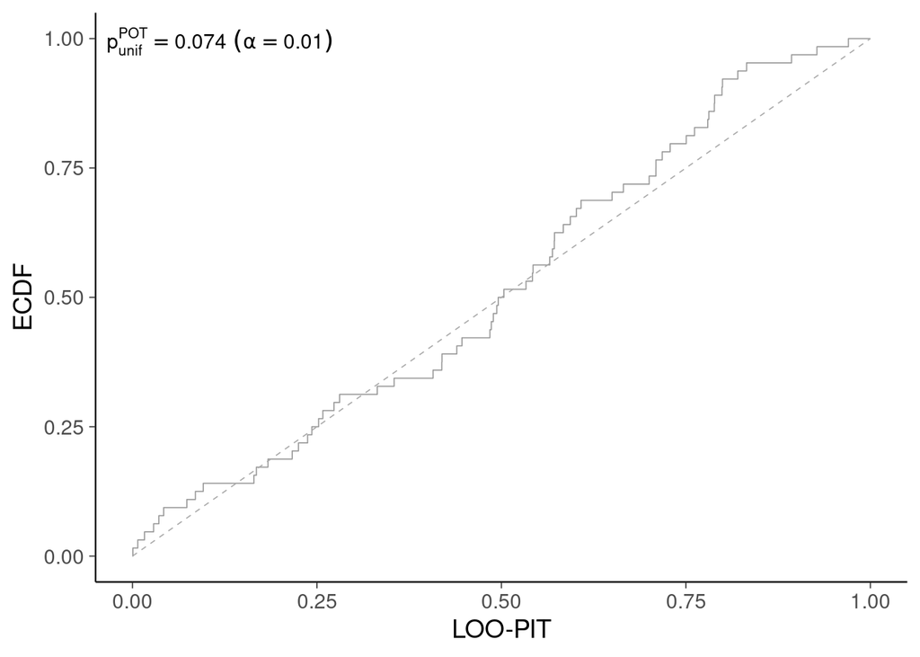

```r
ppc_loo_pit_ecdf(
  y = stan_data$score_1 - stan_data$score_2,
  yrep = fit_bipois$draws(format = "matrix", variables = "y_rep"),
  psis_object = loo_bipois$psis_object,
  method = "correlated"
)
```

LOO-CV predictive checking with LOO-PIT for the Poisson difference model looks fine.

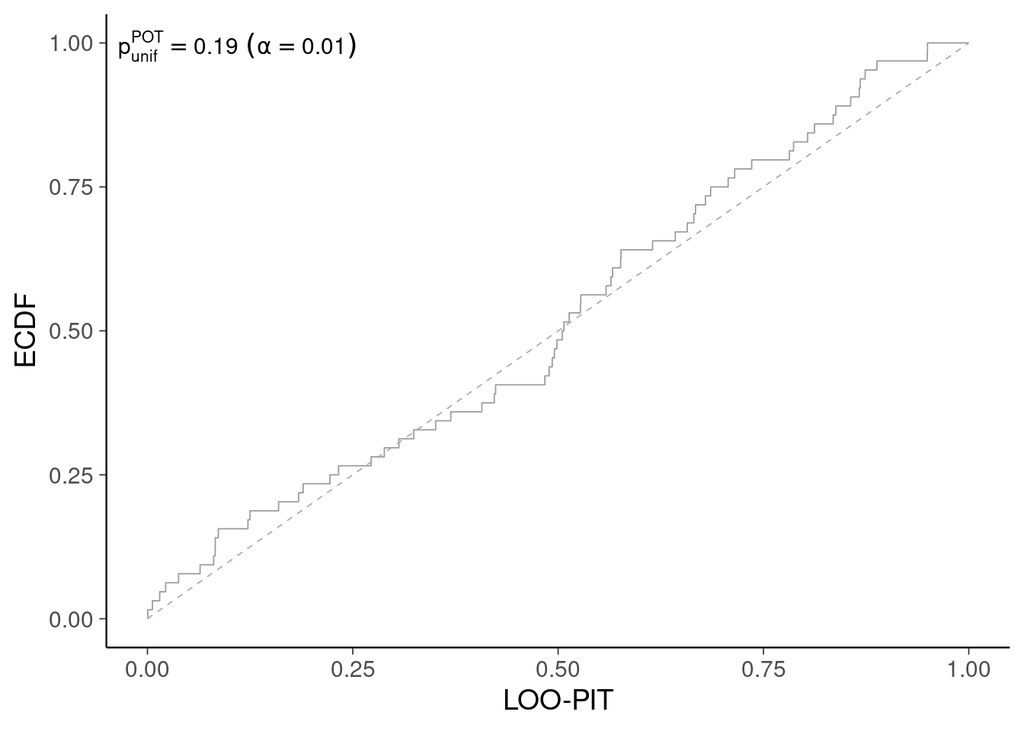

```r
ppc_loo_pit_ecdf(
  y = stan_data$score_1 - stan_data$score_2,
  yrep = fit_poisdif$draws(format = "matrix", variables = "y_rep"),
  psis_object = loo_poisdif$psis_object,
  method = "correlated"
)
```

In this case study, we used many other models for illustration, but for real football score modeling, it is a good idea to start with the bivariate Poisson model. For real football analysis footBayes R package (Egidi, Macrì Demartino, and Palaskas 2025) has several different models including dynamic models allowing the latent performance to evolve in time.

# References

Egidi, Leonardo, Roberto Macrì Demartino, and Vasilis Palaskas. 2025. *footBayes: Fitting Bayesian and MLE Football Models*. https://CRAN.R-project.org/package=footBayes.

Karlis, D., and I. Ntzoufras. 2003. “Analysis of Sports Data by Using Bivariate Poisson Models.” *Journal of the Royal Statistical Society D* 52: 381–93.

Silver, N. 2014. “It’s Brazil’s World Cup to Lose.” *FiveThirtyEight*.

# Licenses

- Code © 2021–2025, Andrew Gelman, Aki Vehtari, licensed under BSD-3.
- Text © 2021–2025, Andrew Gelman, Aki Vehtari, licensed under CC-BY-NC 4.0.